# Concrete Project

```python
#Installation
#!pip install boruta

#installation
#!pip install xgboost
```

```python
import pandas as pd
import numpy as np
import matplotlib.pyplot as plt
import seaborn as sns
import warnings
warnings.filterwarnings('ignore')
```

```python
concrete_df = pd.read_csv('concrete.csv')
```

```python
concrete_df.head()
```

|  | cement | slag | ash | water | superplastic | coarseagg | fineagg | age | strength |
| --- | --- | --- | --- | --- | --- | --- | --- | --- | --- |
| 0 | 141.3 | 212.0 | 0.0 | 203.5 | 0.0 | 971.8 | 748.5 | 28 | 29.89 |
| 1 | 168.9 | 42.2 | 124.3 | 158.3 | 10.8 | 1080.8 | 796.2 | 14 | 23.51 |
| 2 | 250.0 | 0.0 | 95.7 | 187.4 | 5.5 | 956.9 | 861.2 | 28 | 29.22 |
| 3 | 266.0 | 114.0 | 0.0 | 228.0 | 0.0 | 932.0 | 670.0 | 28 | 45.85 |
| 4 | 154.8 | 183.4 | 0.0 | 193.3 | 9.1 | 1047.4 | 696.7 | 28 | 18.29 |

Summary Statistics:

Number of instances (observations): 1030

Number of Attributes: 9

Attribute breakdown: 8 quantitative input variables, and 1 quantitative output variable

Variable Information:

Name -- Data Type -- Measurement -- Description

Cement (component 1) -- quantitative -- kg in a m3 mixture -- Input Variable

Blast Furnace Slag (component 2) -- quantitative -- kg in a m3 mixture -- Input Variable

Fly Ash (component 3) -- quantitative -- kg in a m3 mixture -- Input Variable

Water (component 4) -- quantitative -- kg in a m3 mixture -- Input Variable

Superplasticizer (component 5) -- quantitative -- kg in a m3 mixture -- Input Variable

Coarse Aggregate (component 6) -- quantitative -- kg in a m3 mixture -- Input Variable

Fine Aggregate (component 7) -- quantitative -- kg in a m3 mixture -- Input Variable

Age -- quantitative -- Day (1~365) -- Input Variable

Concrete compressive strength -- quantitative -- MPa -- Output Variable

```python
concrete_df.info()
```

```
<class 'pandas.core.frame.DataFrame'>
RangeIndex: 1030 entries, 0 to 1029
Data columns (total 9 columns):
cement          1030 non-null float64
slag            1030 non-null float64
ash             1030 non-null float64
water           1030 non-null float64
superplastic    1030 non-null float64
coarseagg       1030 non-null float64
fineagg         1030 non-null float64
age             1030 non-null int64
strength        1030 non-null float64
dtypes: float64(8), int64(1)
memory usage: 72.5 KB
```

There are no missing values in the dataset and all the data are in numerical datatype

```python
concrete_df.describe().transpose()
```

|  | count | mean | std | min | 25% | 50% | 75% | max |
| --- | --- | --- | --- | --- | --- | --- | --- | --- |
| cement | 1030.0 | 281.167864 | 104.506364 | 102.00 | 192.375 | 272.900 | 350.000 | 540.0 |
| slag | 1030.0 | 73.895825 | 86.279342 | 0.00 | 0.000 | 22.000 | 142.950 | 359.4 |
| ash | 1030.0 | 54.188350 | 63.997004 | 0.00 | 0.000 | 0.000 | 118.300 | 200.1 |
| water | 1030.0 | 181.567282 | 21.354219 | 121.80 | 164.900 | 185.000 | 192.000 | 247.0 |
| superplastic | 1030.0 | 6.204660 | 5.973841 | 0.00 | 0.000 | 6.400 | 10.200 | 32.2 |
| coarseagg | 1030.0 | 972.918932 | 77.753954 | 801.00 | 932.000 | 968.000 | 1029.400 | 1145.0 |
| fineagg | 1030.0 | 773.580485 | 80.175980 | 594.00 | 730.950 | 779.500 | 824.000 | 992.6 |
| age | 1030.0 | 45.662136 | 63.169912 | 1.00 | 7.000 | 28.000 | 56.000 | 365.0 |
| strength | 1030.0 | 35.817961 | 16.705742 | 2.33 | 23.710 | 34.445 | 46.135 | 82.6 |

- The univariate analysis of the attributes is desribed. The slag attributes have long tails to right as the mean is closer to min than its max value

```
array([[<matplotlib.axes._subplots.AxesSubplot object at 0x000002C431CD4DD8>,
      dtype=object)
```

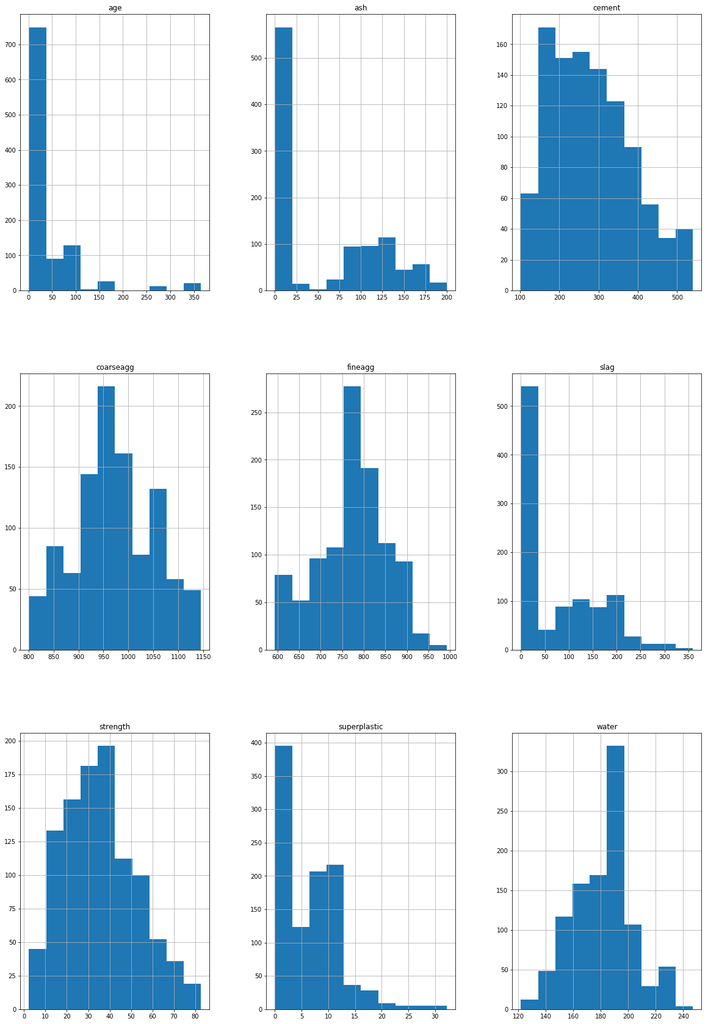

```python
concrete_df.hist(figsize = (20,30))
```

```
cement             AxesSubplot(0.125,0.657941;0.227941x0.222059)
slag            AxesSubplot(0.398529,0.657941;0.227941x0.222059)
ash             AxesSubplot(0.672059,0.657941;0.227941x0.222059)
water              AxesSubplot(0.125,0.391471;0.227941x0.222059)
superplastic    AxesSubplot(0.398529,0.391471;0.227941x0.222059)
coarseagg       AxesSubplot(0.672059,0.391471;0.227941x0.222059)
fineagg               AxesSubplot(0.125,0.125;0.227941x0.222059)
age                AxesSubplot(0.398529,0.125;0.227941x0.222059)
strength           AxesSubplot(0.672059,0.125;0.227941x0.222059)
dtype: object
```

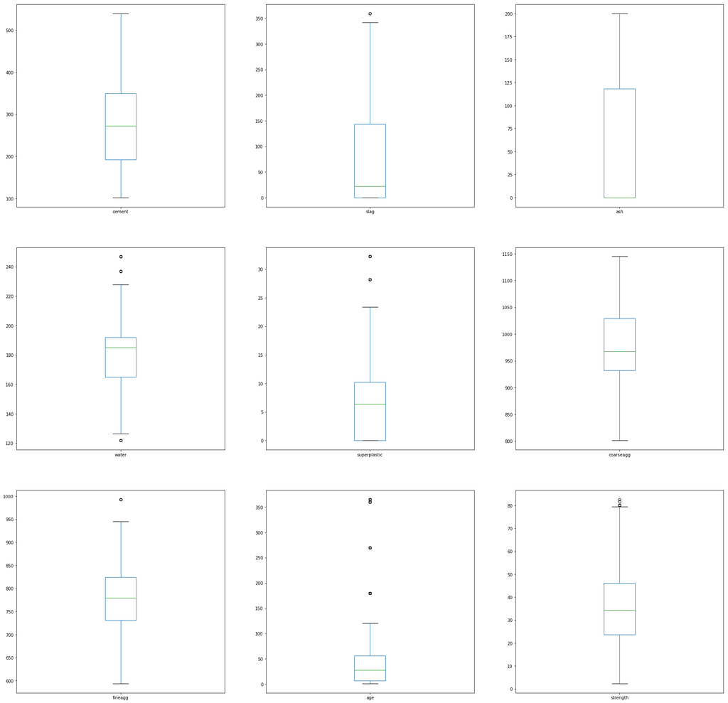

```python
concrete_df.plot(kind = 'box', figsize = (30,30), subplots = True, layout = (3,3))
```

As can be seen, there are outliers in the dataset which are to be addressed before starting the modelling

```python
# Copying the original dataframe
concrete_df1 = concrete_df.copy(deep = True)
```

# Dealing with Outliers of the dataset

```python
column_outliers = ['cement', 'ash', 'slag', 'water', 'superplastic', 'coarseagg', 'fineagg', 'age', 'strength']

for i in column_outliers:
    dp75,dp25 = np.percentile(concrete_df1[i], [75,25])
    IQR = dp75 - dp25
    Up_limit = dp75 + 1.5 * IQR
    Low_limit = dp25 - 1.5 * IQR
    median = concrete_df1[i].median()
    print('Count of outliers of', i)
    print('Number of outliers in the upper range is ', concrete_df1[concrete_df1[i] > Up_limit][i].shape[0])
    print('Number of outliers in the lower range is ', concrete_df1[concrete_df1[i] < Low_limit][i].shape[0])
  #  concrete_df1.loc[(concrete_df1[i] > Up_limit),i] = median
  #  concrete_df1.loc[(concrete_df1[i] < Low_limit),i] = median

    print('*' * 100)
```

```
Count of outliers of cement
Number of outliers in the upper range is  0
Number of outliers in the lower range is  0
Count of outliers of ash
Number of outliers in the upper range is  0
Number of outliers in the lower range is  0
Count of outliers of slag
Number of outliers in the upper range is  2
Number of outliers in the lower range is  0
Count of outliers of water
Number of outliers in the upper range is  4
Number of outliers in the lower range is  5
Count of outliers of superplastic
Number of outliers in the upper range is  10
Number of outliers in the lower range is  0
Count of outliers of coarseagg
Number of outliers in the upper range is  0
Number of outliers in the lower range is  0
Count of outliers of fineagg
Number of outliers in the upper range is  5
Number of outliers in the lower range is  0
Count of outliers of age
Number of outliers in the upper range is  59
Number of outliers in the lower range is  0
Count of outliers of strength
Number of outliers in the upper range is  4
Number of outliers in the lower range is  0
```

- Outliers of attributes are better to be replaced with nearest values like (mean + 2sigma) for upper range outliers and (mean - 2sigma) for lower range outliers

```python
# Replacing the outliers with suitable values for the independent variables only

column_outliers = [ 'slag', 'water', 'superplastic', 'fineagg', 'age']

for i in column_outliers:
    dp75,dp25 = np.percentile(concrete_df1[i], [75,25])
    IQR = dp75 - dp25
    Up_limit = dp75 + 1.5 * IQR
    Low_limit = dp25 - 1.5 * IQR
    mean = concrete_df1[i].mean()
    std = concrete_df1[i].std()
    print('Number of outliers in the upper range is ', concrete_df1[concrete_df1[i] > Up_limit][i].shape[0])
    print('Number of outliers in the lower range is ', concrete_df1[concrete_df1[i] < Low_limit][i].shape[0])
    concrete_df1.loc[(concrete_df1[i] >Up_limit),i] = mean + 2 * std
    concrete_df1.loc[(concrete_df1[i] < Low_limit),i] = mean - 2 * std
    msg = " Upper outliers are replaced by %.2f and Lower outliers if any are replaced by %.2f" % ((mean + 2 *std), (mean - 2 * std))
    print(msg)
    print('All the outliers are replaced of ', i)
    print('*' * 100)
```

```
Number of outliers in the upper range is  2
Number of outliers in the lower range is  0
 Upper outliers are replaced by 246.45 and Lower outliers if any are replaced by -98.66
All the outliers are replaced of  slag
Number of outliers in the upper range is  4
Number of outliers in the lower range is  5
 Upper outliers are replaced by 224.28 and Lower outliers if any are replaced by 138.86
All the outliers are replaced of  water
Number of outliers in the upper range is  10
Number of outliers in the lower range is  0
 Upper outliers are replaced by 18.15 and Lower outliers if any are replaced by -5.74
All the outliers are replaced of  superplastic
Number of outliers in the upper range is  5
Number of outliers in the lower range is  0
 Upper outliers are replaced by 933.93 and Lower outliers if any are replaced by 613.23
All the outliers are replaced of  fineagg
Number of outliers in the upper range is  59
Number of outliers in the lower range is  0
 Upper outliers are replaced by 172.00 and Lower outliers if any are replaced by -80.68
All the outliers are replaced of  age
```

```
cement             AxesSubplot(0.125,0.657941;0.227941x0.222059)
slag            AxesSubplot(0.398529,0.657941;0.227941x0.222059)
ash             AxesSubplot(0.672059,0.657941;0.227941x0.222059)
water              AxesSubplot(0.125,0.391471;0.227941x0.222059)
superplastic    AxesSubplot(0.398529,0.391471;0.227941x0.222059)
coarseagg       AxesSubplot(0.672059,0.391471;0.227941x0.222059)
fineagg               AxesSubplot(0.125,0.125;0.227941x0.222059)
age                AxesSubplot(0.398529,0.125;0.227941x0.222059)
strength           AxesSubplot(0.672059,0.125;0.227941x0.222059)
dtype: object
```

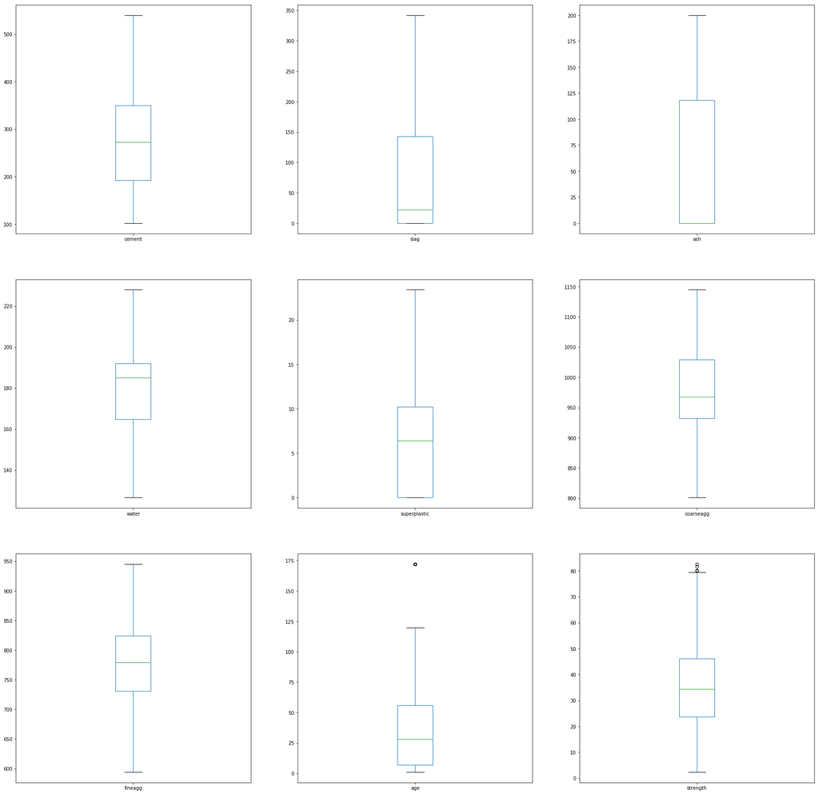

```python
concrete_df1.plot(kind = 'box', figsize = (30,30), subplots = True, layout = (3,3))
```

- only few outliers are lift out after imputation

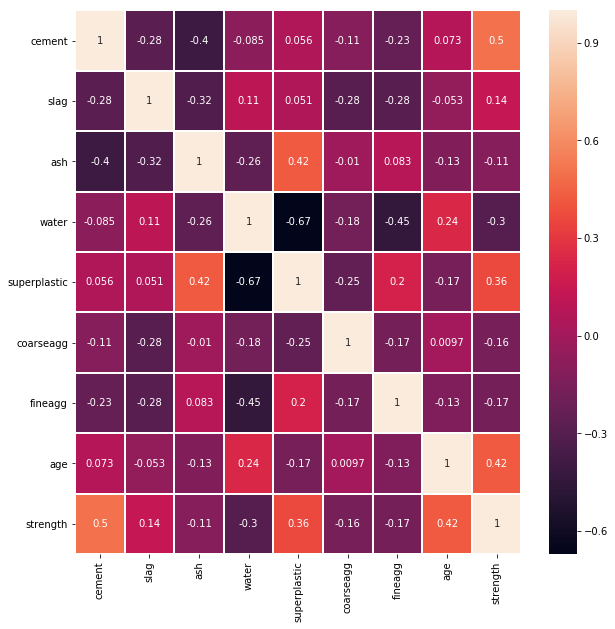

```python
corr = concrete_df1.corr()
plt.figure(figsize = (10,10))
sns.heatmap(corr, annot = True, linewidths = 1 )
```

[figure not shown]

```python
plt.figure(figsize = (20,20))
sns.pairplot(concrete_df1, diag_kind = 'hist')
```

- Maximum data is distributed as a cloud in the pair plot, and only a marginal linear relation between the models as even seen in correlation matrix
- Some kind of linear relation can be seen between strength and cement content

```
array([[<matplotlib.axes._subplots.AxesSubplot object at 0x000002C427EBE5C0>,
      dtype=object)
```

[figure not shown]

```python
concrete_df1.plot(kind = 'kde', subplots = True, sharex = False, sharey = False, layout = (3,4), figsize = (25,25))
```

The cement and strength distribution almost follows a normal distribution pattern

```python
from sklearn import preprocessing
```

```python
x_array = np.array(concrete_df1['cement'])
norm_cement = preprocessing.normalize([x_array])

x_array1 = np.array(concrete_df1['slag'])
norm_slag = preprocessing.normalize([x_array1])

x_array2 = np.array(concrete_df1['ash'])
norm_ash = preprocessing.normalize([x_array2])

x_array3 = np.array(concrete_df1['water'])
norm_water = preprocessing.normalize([x_array3])

x_array4 = np.array(concrete_df1['superplastic'])
norm_superplastic = preprocessing.normalize([x_array4])

x_array5 = np.array(concrete_df1['coarseagg'])
norm_coarseagg = preprocessing.normalize([x_array5])

x_array6 = np.array(concrete_df1['fineagg'])
norm_fineagg = preprocessing.normalize([x_array6])

x_array7 = np.array(concrete_df1['age'])
norm_age = preprocessing.normalize([x_array7])

x_array8 = np.array(concrete_df1['strength'])
norm_strength = preprocessing.normalize([x_array8])
```

```python
concrete_df1_norm =   pd.DataFrame({'cement': norm_cement[0,:], 'slag': norm_slag[0,:], 'ash': norm_ash[0,:], 'water': norm_water[0,:],
                                 'superplastic' : norm_superplastic[0,:], 'coarseagg' : norm_coarseagg[0,:], 'fineagg' : norm_fineagg[0,:],
                                 'age' : norm_age[0,:], 'strength' : norm_strength[0,:]
                                 })
concrete_df1_norm.head()
```

|  | cement | slag | ash | water | superplastic | coarseagg | fineagg | age | strength |
| --- | --- | --- | --- | --- | --- | --- | --- | --- | --- |
| 0 | 0.014679 | 0.058467 | 0.000000 | 0.034689 | 0.000000 | 0.031024 | 0.030002 | 0.014827 | 0.023567 |
| 1 | 0.017546 | 0.011638 | 0.046199 | 0.026984 | 0.040673 | 0.034504 | 0.031914 | 0.007413 | 0.018537 |
| 2 | 0.025971 | 0.000000 | 0.035569 | 0.031945 | 0.020713 | 0.030549 | 0.034519 | 0.014827 | 0.023039 |
| 3 | 0.027633 | 0.031440 | 0.000000 | 0.038866 | 0.000000 | 0.029754 | 0.026855 | 0.014827 | 0.036151 |
| 4 | 0.016081 | 0.050580 | 0.000000 | 0.032951 | 0.034270 | 0.033438 | 0.027925 | 0.014827 | 0.014421 |

# ITERATION 1 : LINEAR MODEL WITH REGULARIZATION

```python
from scipy.stats import zscore

# splitting the dataframe into features and target variable
X = concrete_df1_norm.iloc[:,0:8]
X_z = X.apply(zscore)
y = concrete_df1.iloc[:,8]
X_z.head()
```

|  | cement | slag | ash | water | superplastic | coarseagg | fineagg | age |
| --- | --- | --- | --- | --- | --- | --- | --- | --- |
| 0 | -1.339017 | 1.614934 | -0.847144 | 1.045009 | -1.086474 | -0.014398 | -0.312054 | -0.292971 |
| 1 | -1.074790 | -0.367490 | 1.096078 | -1.110007 | 0.841008 | 1.388141 | 0.288251 | -0.620969 |
| 2 | -0.298384 | -0.860177 | 0.648965 | 0.277404 | -0.104886 | -0.206121 | 1.106277 | -0.292971 |
| 3 | -0.145209 | 0.470779 | -0.847144 | 2.213104 | -1.086474 | -0.526517 | -1.299978 | -0.292971 |
| 4 | -1.209776 | 1.281027 | -0.847144 | 0.558700 | 0.537608 | 0.958372 | -0.963958 | -0.292971 |

```python
y.head()
```

```
0    29.89
1    23.51
2    29.22
3    45.85
4    18.29
Name: strength, dtype: float64
```

```python
from sklearn.model_selection import train_test_split

from sklearn.model_selection import cross_val_score, cross_val_predict

from sklearn.model_selection import KFold

from sklearn.linear_model import LinearRegression, Lasso, Ridge

from sklearn.neighbors import KNeighborsRegressor

from sklearn.tree import DecisionTreeRegressor

from sklearn.naive_bayes import GaussianNB

from sklearn.svm import SVR

from sklearn.ensemble import GradientBoostingRegressor

from sklearn.ensemble import RandomForestRegressor

import xgboost as xgb

from sklearn.preprocessing import PolynomialFeatures

import statsmodels.api as sm

from sklearn.model_selection import GridSearchCV


X_train,X_test,y_train,y_test = train_test_split(X_z,y,test_size = 0.3, random_state = 20)
```

```python
from sklearn.linear_model import LinearRegression
clfLR = LinearRegression()
LR_model = clfLR.fit(X_train,y_train)
print(LR_model.coef_)
print(LR_model.singular_)
```

```
[11.12831152  7.55074432  3.91505996 -4.42976939  2.02610784  0.49065817
  0.18368523  8.43844627]
[40.90603044 32.29953092 30.90859648 27.20704514 26.14339194 24.33987486
 11.00098316  4.70156357]
```

```python
LR_model.score(X_train,y_train)
```

```
0.7022241434884235
```

- Base model with Linear Regression has an accuracy of 70.2%

```python
ridge = Ridge(alpha = 0.3)
ridge.fit(X_train,y_train)
```

```
Ridge(alpha=0.3, copy_X=True, fit_intercept=True, max_iter=None,
   normalize=False, random_state=None, solver='auto', tol=0.001)
```

- Creating a regularized Lasso model and getting its co-efficients

```python
lasso = Lasso(alpha = 0.3)
lasso.fit(X_train,y_train)
```

```
Lasso(alpha=0.3, copy_X=True, fit_intercept=True, max_iter=1000,
   normalize=False, positive=False, precompute=False, random_state=None,
   selection='cyclic', tol=0.0001, warm_start=False)
```

```python
linearmodel  =   {'Attributes' : ['cement', 'slag', 'ash','water','superplastic','coarseagg','fineagg','age'],
                             'Linear Regression' : np.array(LR_model.coef_),
                             'Ridge Regularization' : np.array(ridge.coef_),
                             'Lasso Regularization' : np.array(lasso.coef_),
                    }
Linear_model = pd.DataFrame(data = linearmodel)
Linear_model
```

|  | Attributes | Linear Regression | Ridge Regularization | Lasso Regularization |
| --- | --- | --- | --- | --- |
| 0 | cement | 11.128312 | 11.072727 | 9.435061 |
| 1 | slag | 7.550744 | 7.496291 | 5.817724 |
| 2 | ash | 3.915060 | 3.867117 | 2.159828 |
| 3 | water | -4.429769 | -4.463589 | -4.470230 |
| 4 | superplastic | 2.026108 | 2.028347 | 2.566125 |
| 5 | coarseagg | 0.490658 | 0.454746 | -0.000000 |
| 6 | fineagg | 0.183685 | 0.136800 | -0.510934 |
| 7 | age | 8.438446 | 8.432401 | 7.946387 |

- There is no marginal reduction in the co-efficients of Linear Regression and Ridge Regularization
- The Lasso Regularization reduces coarseagg co-efficeint to 'zero' and increases the importance of 'fineagg'
- Performance of Linear regression, Ridge and Lasso models

```python
y_predict = LR_model.predict(X_test)
print(LR_model.score(X_train,y_train))
print(LR_model.score(X_test,y_test))
```

```
0.7022241434884235
0.6832960110433788
```

```python
print(ridge.score(X_train,y_train))
print(ridge.score(X_test,y_test))
```

```
0.7022224414593656
0.683107989135414
```

```python
print(lasso.score(X_train,y_train))
print(lasso.score(X_test,y_test))
```

```
0.6977764035522669
0.6718001896573593
```

```python
print(lasso.get_params)
```

```
<bound method BaseEstimator.get_params of Lasso(alpha=0.3, copy_X=True, fit_intercept=True, max_iter=1000,
   normalize=False, positive=False, precompute=False, random_state=None,
   selection='cyclic', tol=0.0001, warm_start=False)>
```

```python
# Grid search of the hyperparameter of ridge and lasso regularization
```

```python
param_grid = { 'alpha': [0.001,0.01,0.1,0.5,1]}
```

```python
grid_search_ridge = GridSearchCV(estimator = ridge, param_grid = param_grid, scoring = 'r2', cv = 3,n_jobs = -1,verbose = 3)
```

```python
grid_search_lasso = GridSearchCV(estimator = lasso, param_grid = param_grid, scoring = 'r2',cv = 3 ,n_jobs = -1,verbose = 3)
```

```python
grid_search_ridge.fit(X_train,y_train)
```

```
Fitting 3 folds for each of 5 candidates, totalling 15 fits
```

```
[Parallel(n_jobs=-1)]: Using backend LokyBackend with 4 concurrent workers.
[Parallel(n_jobs=-1)]: Done  15 out of  15 | elapsed:    5.7s finished
```

```
GridSearchCV(cv=3, error_score='raise-deprecating',
       estimator=Ridge(alpha=0.3, copy_X=True, fit_intercept=True, max_iter=None,
   normalize=False, random_state=None, solver='auto', tol=0.001),
       fit_params=None, iid='warn', n_jobs=-1,
       param_grid={'alpha': [0.001, 0.01, 0.1, 0.5, 1]},
       pre_dispatch='2*n_jobs', refit=True, return_train_score='warn',
       scoring='r2', verbose=3)
```

```python
final_ridge = grid_search_ridge.best_estimator_
final_ridge
```

```
Ridge(alpha=1, copy_X=True, fit_intercept=True, max_iter=None,
   normalize=False, random_state=None, solver='auto', tol=0.001)
```

```python
grid_search_lasso.fit(X_train,y_train)
```

```
Fitting 3 folds for each of 5 candidates, totalling 15 fits
```

```
[Parallel(n_jobs=-1)]: Using backend LokyBackend with 4 concurrent workers.
[Parallel(n_jobs=-1)]: Done   8 out of  15 | elapsed:    0.0s remaining:    0.0s
[Parallel(n_jobs=-1)]: Done  15 out of  15 | elapsed:    0.0s finished
```

```
GridSearchCV(cv=3, error_score='raise-deprecating',
       estimator=Lasso(alpha=0.3, copy_X=True, fit_intercept=True, max_iter=1000,
   normalize=False, positive=False, precompute=False, random_state=None,
   selection='cyclic', tol=0.0001, warm_start=False),
       fit_params=None, iid='warn', n_jobs=-1,
       param_grid={'alpha': [0.001, 0.01, 0.1, 0.5, 1]},
       pre_dispatch='2*n_jobs', refit=True, return_train_score='warn',
       scoring='r2', verbose=3)
```

```python
final_lasso = grid_search_lasso.best_estimator_
final_lasso
```

```
Lasso(alpha=0.1, copy_X=True, fit_intercept=True, max_iter=1000,
   normalize=False, positive=False, precompute=False, random_state=None,
   selection='cyclic', tol=0.0001, warm_start=False)
```

```python
final_ridge.score(X_test,y_test)
```

```
0.6826751698630413
```

```python
final_lasso.score(X_test,y_test)
```

```
0.6796237441465566
```

- There is no significant increase in score after regularization of apha in ridge and lasso

```python
y_pred = LR_model.predict(X_test)
```

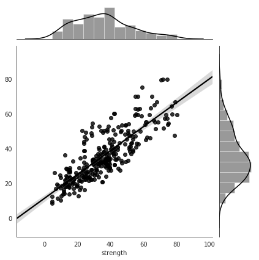

```python
with sns.axes_style("white"):
    sns.jointplot(x=y_test, y = y_pred, kind = 'reg', color = 'k')
```

- There is no significant use in regularising and hyper parameter tuning of the linear model using ridge and lasso regularization.
- Lets go for increasing the degree of the the polynomial

# ITERATION 2 : POLYNOMIAL REGRESSION

```python
from sklearn.preprocessing import PolynomialFeatures
```

```python
poly = PolynomialFeatures(degree = 3, interaction_only = True)
```

```python
X_poly = poly.fit_transform(X_z)
```

```python
X_trainp,X_testp,y_trainp,y_testp = train_test_split(X_poly,y,test_size = 0.3, random_state = 1)
```

```python
X_trainp.shape
```

```
(721, 93)
```

```python
LR_model_p = LinearRegression()
LR_model_p.fit(X_trainp,y_trainp)
```

```
LinearRegression(copy_X=True, fit_intercept=True, n_jobs=None,
         normalize=False)
```

```python
poly_OLS = sm.OLS(y_trainp,X_trainp).fit()
poly_OLS.summary()
```

OLS Regression Results

| Dep. Variable: | strength | R-squared: | 0.835 |
| --- | --- | --- | --- |
| Model: | OLS | Adj. R-squared: | 0.811 |
| Method: | Least Squares | F-statistic: | 34.60 |
| Date: | Sat, 29 Jun 2019 | Prob (F-statistic): | 1.82e-192 |
| Time: | 14:44:39 | Log-Likelihood: | -2396.0 |
| No. Observations: | 721 | AIC: | 4978. |
| Df Residuals: | 628 | BIC: | 5404. |
| Df Model: | 92 |  |  |
| Covariance Type: | nonrobust |  |  |

|  | coef | std err | t | P>\|t\| | [0.025 | 0.975] |
| --- | --- | --- | --- | --- | --- | --- |
| const | 41.1793 | 1.264 | 32.581 | 0.000 | 38.697 | 43.661 |
| x1 | 14.3724 | 1.769 | 8.124 | 0.000 | 10.898 | 17.846 |
| x2 | 10.6498 | 1.843 | 5.778 | 0.000 | 7.030 | 14.269 |
| x3 | 7.7900 | 1.793 | 4.344 | 0.000 | 4.269 | 11.311 |
| x4 | -1.5522 | 1.520 | -1.021 | 0.308 | -4.537 | 1.433 |
| x5 | 3.3385 | 1.506 | 2.217 | 0.027 | 0.381 | 6.296 |
| x6 | 1.4409 | 1.353 | 1.065 | 0.287 | -1.215 | 4.097 |
| x7 | 2.6457 | 1.606 | 1.647 | 0.100 | -0.509 | 5.800 |
| x8 | 13.6022 | 1.801 | 7.552 | 0.000 | 10.065 | 17.139 |
| x9 | -0.6761 | 1.091 | -0.620 | 0.536 | -2.818 | 1.466 |
| x10 | 1.4479 | 1.165 | 1.242 | 0.215 | -0.841 | 3.736 |
| x11 | -0.6090 | 1.252 | -0.486 | 0.627 | -3.067 | 1.849 |
| x12 | -0.4523 | 1.643 | -0.275 | 0.783 | -3.678 | 2.774 |
| x13 | -0.2809 | 0.867 | -0.324 | 0.746 | -1.984 | 1.422 |
| x14 | 2.4750 | 0.830 | 2.984 | 0.003 | 0.846 | 4.104 |
| x15 | -0.0281 | 2.444 | -0.012 | 0.991 | -4.827 | 4.771 |
| x16 | 2.9833 | 1.359 | 2.195 | 0.029 | 0.314 | 5.653 |
| x17 | 0.3579 | 1.510 | 0.237 | 0.813 | -2.608 | 3.324 |
| x18 | -1.0531 | 1.971 | -0.534 | 0.593 | -4.924 | 2.817 |
| x19 | -0.6523 | 1.014 | -0.643 | 0.520 | -2.643 | 1.338 |
| x20 | 2.1479 | 0.947 | 2.268 | 0.024 | 0.288 | 4.007 |
| x21 | 2.2892 | 2.196 | 1.042 | 0.298 | -2.024 | 6.602 |
| x22 | 1.2961 | 1.391 | 0.932 | 0.352 | -1.435 | 4.028 |
| x23 | -2.7024 | 1.869 | -1.446 | 0.149 | -6.372 | 0.967 |
| x24 | -0.2108 | 1.029 | -0.205 | 0.838 | -2.232 | 1.810 |
| x25 | 4.2468 | 1.190 | 3.570 | 0.000 | 1.911 | 6.583 |
| x26 | 2.8373 | 2.316 | 1.225 | 0.221 | -1.711 | 7.386 |
| x27 | 0.2012 | 1.109 | 0.181 | 0.856 | -1.976 | 2.379 |
| x28 | -2.3737 | 0.767 | -3.095 | 0.002 | -3.880 | -0.868 |
| x29 | -0.0497 | 0.805 | -0.062 | 0.951 | -1.631 | 1.532 |

[output cut: 63 more lines]

| Omnibus: | 4.813 | Durbin-Watson: | 2.013 |
| --- | --- | --- | --- |
| Prob(Omnibus): | 0.090 | Jarque-Bera (JB): | 5.886 |
| Skew: | -0.047 | Prob(JB): | 0.0527 |
| Kurtosis: | 3.433 | Cond. No. | 128. |

Warnings:  
[1] Standard Errors assume that the covariance matrix of the errors is correctly specified.

```python
ridge_p = Ridge(alpha = 0.3)
ridge_p.fit(X_trainp,y_trainp)
```

```
Ridge(alpha=0.3, copy_X=True, fit_intercept=True, max_iter=None,
   normalize=False, random_state=None, solver='auto', tol=0.001)
```

```python
lasso_p= Lasso(alpha = 0.3)
lasso_p.fit(X_trainp,y_trainp)
```

```
Lasso(alpha=0.3, copy_X=True, fit_intercept=True, max_iter=1000,
   normalize=False, positive=False, precompute=False, random_state=None,
   selection='cyclic', tol=0.0001, warm_start=False)
```

```python
print(LR_model_p.score(X_trainp,y_trainp))
print(LR_model_p.score(X_testp,y_testp))
```

```
0.8352111775424257
0.7675895596130021
```

```python
print(ridge_p.score(X_trainp,y_trainp))
print(ridge_p.score(X_testp,y_testp))
```

```
0.8351681940122535
0.7685631435852748
```

```python
print(lasso_p.score(X_trainp,y_trainp))
print(lasso_p.score(X_testp,y_testp))
```

```
0.7875617976593705
0.7570481690171391
```

```python
param_grid = { 'alpha': [0.001,0.01,0.1,0.5,1]
             }
```

```python
grid_search_ridge_p = GridSearchCV(estimator = ridge_p, param_grid = param_grid, scoring = 'r2', cv = 3,n_jobs = -1,verbose = 3)
```

```python
grid_search_lasso_p = GridSearchCV(estimator = lasso_p, param_grid = param_grid, scoring = 'r2',cv = 3 ,n_jobs = -1,verbose = 3)
```

```python
grid_search_ridge_p.fit(X_trainp,y_trainp)
```

```
Fitting 3 folds for each of 5 candidates, totalling 15 fits
```

```
[Parallel(n_jobs=-1)]: Using backend LokyBackend with 4 concurrent workers.
[Parallel(n_jobs=-1)]: Done   8 out of  15 | elapsed:    0.0s remaining:    0.0s
[Parallel(n_jobs=-1)]: Done  15 out of  15 | elapsed:    0.0s finished
```

```
GridSearchCV(cv=3, error_score='raise-deprecating',
       estimator=Ridge(alpha=0.3, copy_X=True, fit_intercept=True, max_iter=None,
   normalize=False, random_state=None, solver='auto', tol=0.001),
       fit_params=None, iid='warn', n_jobs=-1,
       param_grid={'alpha': [0.001, 0.01, 0.1, 0.5, 1]},
       pre_dispatch='2*n_jobs', refit=True, return_train_score='warn',
       scoring='r2', verbose=3)
```

```python
final_ridge_polynomial3 = grid_search_ridge_p.best_estimator_
final_ridge_polynomial3
```

```
Ridge(alpha=1, copy_X=True, fit_intercept=True, max_iter=None,
   normalize=False, random_state=None, solver='auto', tol=0.001)
```

```python
grid_search_lasso_p.fit(X_trainp,y_trainp)
```

```
Fitting 3 folds for each of 5 candidates, totalling 15 fits
```

```
[Parallel(n_jobs=-1)]: Using backend LokyBackend with 4 concurrent workers.
[Parallel(n_jobs=-1)]: Done   8 out of  15 | elapsed:    0.2s remaining:    0.1s
[Parallel(n_jobs=-1)]: Done  15 out of  15 | elapsed:    0.2s finished
```

```
GridSearchCV(cv=3, error_score='raise-deprecating',
       estimator=Lasso(alpha=0.3, copy_X=True, fit_intercept=True, max_iter=1000,
   normalize=False, positive=False, precompute=False, random_state=None,
   selection='cyclic', tol=0.0001, warm_start=False),
       fit_params=None, iid='warn', n_jobs=-1,
       param_grid={'alpha': [0.001, 0.01, 0.1, 0.5, 1]},
       pre_dispatch='2*n_jobs', refit=True, return_train_score='warn',
       scoring='r2', verbose=3)
```

```python
final_lasso_polynomial3 = grid_search_lasso_p.best_estimator_
final_lasso_polynomial3
```

```
Lasso(alpha=0.1, copy_X=True, fit_intercept=True, max_iter=1000,
   normalize=False, positive=False, precompute=False, random_state=None,
   selection='cyclic', tol=0.0001, warm_start=False)
```

```python
grid_search_ridge_p.best_estimator_
```

```
Ridge(alpha=1, copy_X=True, fit_intercept=True, max_iter=None,
   normalize=False, random_state=None, solver='auto', tol=0.001)
```

```python
grid_search_lasso_p.best_estimator_
```

```
Lasso(alpha=0.1, copy_X=True, fit_intercept=True, max_iter=1000,
   normalize=False, positive=False, precompute=False, random_state=None,
   selection='cyclic', tol=0.0001, warm_start=False)
```

```python
grid_search_ridge_p.score(X_testp,y_testp)
```

```
0.7701455746986061
```

```python
grid_search_lasso_p.score(X_testp,y_testp)
```

```
0.7793976811721729
```

- The polynomial regression with 3 degree gives good score in both training and testing phase. As the polynomial degree increases the model tends to overfit.
- Let us employ other algorithms to achieve score, more than the polynomial regression which is around 83.5% in training set and 76.8% in testing set for 3 degree polynomial ridge

# ITERATION 3 : Regression algorithms

```python
# Initiating Models
clfKNNR = KNeighborsRegressor()
clfDTR = DecisionTreeRegressor(random_state = 0, max_depth = 5)
clfRFR = RandomForestRegressor(random_state = 0, max_depth = 5)
clfSVR = SVR()
clfGBR = GradientBoostingRegressor()
clfXGB = xgb.XGBRegressor()
```

```python
# Creating the matrix of models
Models = []
Models.append(('K-Nearest Neighbour',clfKNNR))
Models.append(('Decision Tree Regressor', clfDTR))
Models.append(('Random Forest Regressor', clfRFR))
Models.append(('Support Vector Classifier', clfSVR))
Models.append(('Gradent Boosting Regressor',clfGBR))
Models.append(('XGBoostRegressor',clfXGB))
```

```python
#Training and Cross validation of different models with confusion matrix, classification report and AUC of ROC-AUC curve
seed = 1000
base_model = []
results = []
names = []
for name,model in Models:
    base_model = model.fit(X_train,y_train)
    score = base_model.score(X_train,y_train)
    kfold = KFold(n_splits=5, shuffle=True, random_state = seed)
    y_predict = cross_val_predict(model,X_train,y_train,cv = kfold)
    results.append(score)
    names.append(name)
    msg = "%s:The accuracy or the R square value is %f" % (name,score)
    print(msg)
```

```
K-Nearest Neighbour:The accuracy or the R square value is 0.848942
Decision Tree Regressor:The accuracy or the R square value is 0.823625
Random Forest Regressor:The accuracy or the R square value is 0.878473
Support Vector Classifier:The accuracy or the R square value is 0.719631
Gradent Boosting Regressor:The accuracy or the R square value is 0.955492
[14:45:18] WARNING: C:/Jenkins/workspace/xgboost-win64_release_0.90/src/objective/regression_obj.cu:152: reg:linear is now deprecated in favor of reg:squarederror.
[14:45:18] WARNING: C:/Jenkins/workspace/xgboost-win64_release_0.90/src/objective/regression_obj.cu:152: reg:linear is now deprecated in favor of reg:squarederror.
[14:45:18] WARNING: C:/Jenkins/workspace/xgboost-win64_release_0.90/src/objective/regression_obj.cu:152: reg:linear is now deprecated in favor of reg:squarederror.
[14:45:18] WARNING: C:/Jenkins/workspace/xgboost-win64_release_0.90/src/objective/regression_obj.cu:152: reg:linear is now deprecated in favor of reg:squarederror.
[14:45:18] WARNING: C:/Jenkins/workspace/xgboost-win64_release_0.90/src/objective/regression_obj.cu:152: reg:linear is now deprecated in favor of reg:squarederror.
[14:45:19] WARNING: C:/Jenkins/workspace/xgboost-win64_release_0.90/src/objective/regression_obj.cu:152: reg:linear is now deprecated in favor of reg:squarederror.
XGBoostRegressor:The accuracy or the R square value is 0.951670
```

```python
#Defining dataframe of classifiers with respective cross validation score mean and AUC of ROC-AUC curve
dtrain = {'Classifiers': [ 'K Nearest Neighbor Regressor', 'Decision Tree Regressor',
                          'Random Forest Regressor' ,'Support Vector Regressor','Gradient Boosting Regressor','XGBoost Regressor'],
                          'Scoring' : np.array(results)
          }
Classifier_dtrain = pd.DataFrame(data = dtrain)
Classifier_dtrain
```

|  | Classifiers | Scoring |
| --- | --- | --- |
| 0 | K Nearest Neighbor Regressor | 0.848942 |
| 1 | Decision Tree Regressor | 0.823625 |
| 2 | Random Forest Regressor | 0.878473 |
| 3 | Support Vector Regressor | 0.719631 |
| 4 | Gradient Boosting Regressor | 0.955492 |
| 5 | XGBoost Regressor | 0.951670 |

- The SVM regressor is not doing well in the training set. Lets use grid search to tune the hyperparameters of SVM, Decision tree regressor and Random Forest Regressor

```python
#Base models used are
Models
```

```
[('K-Nearest Neighbour',
  KNeighborsRegressor(algorithm='auto', leaf_size=30, metric='minkowski',
            metric_params=None, n_jobs=None, n_neighbors=5, p=2,
            weights='uniform')),
 ('Decision Tree Regressor',
  DecisionTreeRegressor(criterion='mse', max_depth=5, max_features=None,
             max_leaf_nodes=None, min_impurity_decrease=0.0,
             min_impurity_split=None, min_samples_leaf=1,
             min_samples_split=2, min_weight_fraction_leaf=0.0,
             presort=False, random_state=0, splitter='best')),
 ('Random Forest Regressor',
  RandomForestRegressor(bootstrap=True, criterion='mse', max_depth=5,
             max_features='auto', max_leaf_nodes=None,
             min_impurity_decrease=0.0, min_impurity_split=None,
             min_samples_leaf=1, min_samples_split=2,
             min_weight_fraction_leaf=0.0, n_estimators=10, n_jobs=None,
             oob_score=False, random_state=0, verbose=0, warm_start=False)),
 ('Support Vector Classifier',
  SVR(C=1.0, cache_size=200, coef0=0.0, degree=3, epsilon=0.1,
    gamma='auto_deprecated', kernel='rbf', max_iter=-1, shrinking=True,
    tol=0.001, verbose=False)),
 ('Gradent Boosting Regressor',
  GradientBoostingRegressor(alpha=0.9, criterion='friedman_mse', init=None,
               learning_rate=0.1, loss='ls', max_depth=3, max_features=None,
               max_leaf_nodes=None, min_impurity_decrease=0.0,
               min_impurity_split=None, min_samples_leaf=1,
               min_samples_split=2, min_weight_fraction_leaf=0.0,
               n_estimators=100, n_iter_no_change=None, presort='auto',
               random_state=None, subsample=1.0, tol=0.0001,
               validation_fraction=0.1, verbose=0, warm_start=False)),
 ('XGBoostRegressor',
  XGBRegressor(base_score=0.5, booster='gbtree', colsample_bylevel=1,
         colsample_bynode=1, colsample_bytree=1, gamma=0,
         importance_type='gain', learning_rate=0.1, max_delta_step=0,
         max_depth=3, min_child_weight=1, missing=None, n_estimators=100,
         n_jobs=1, nthread=None, objective='reg:linear', random_state=0,
         reg_alpha=0, reg_lambda=1, scale_pos_weight=1, seed=None,
         silent=None, subsample=1, verbosity=1))]
```

# Cluster Anaylysis

```python
from sklearn.cluster import KMeans
X_cluster = concrete_df.iloc[:,0:8]
X_cluster.head()
X_cluster_z = X_cluster.apply(zscore)
```

```python
clusters_range = range(1,9)
Errors = []
for num_clusters in clusters_range:
    clusters = KMeans(num_clusters, n_init = 5)
    clusters.fit(X_cluster)
    labels = clusters.labels_
    centroids = clusters.cluster_centers_
    intertia = clusters.inertia_
    Errors.append(intertia)
clusters_df = pd.DataFrame({'cluster_errors' : np.array(Errors), 'number_clusters' : clusters_range, })
```

```python
clusters_df
```

|  | cluster_errors | number_clusters |
| --- | --- | --- |
| 0 | 4.056042e+07 | 1 |
| 1 | 3.123184e+07 | 2 |
| 2 | 2.473715e+07 | 3 |
| 3 | 2.175182e+07 | 4 |
| 4 | 1.969879e+07 | 5 |
| 5 | 1.775302e+07 | 6 |
| 6 | 1.605385e+07 | 7 |
| 7 | 1.436834e+07 | 8 |

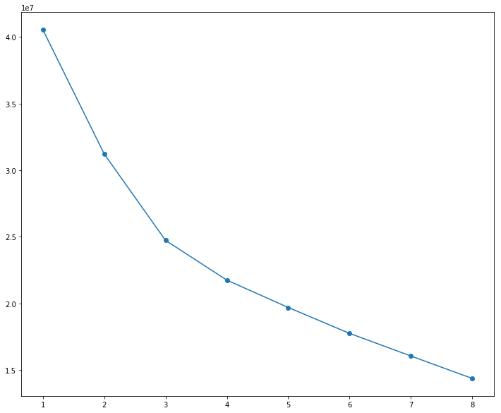

```python
# Elobow Plot
plt.figure(figsize = (12,10))
plt.plot(clusters_df['number_clusters'], clusters_df['cluster_errors'], marker = 'o')
```

- There are about 3 clusters according to the elbow curve

```python
cluster = KMeans(n_clusters = 3, random_state = seed)
```

```python
cluster.fit(X_cluster_z)
```

```
KMeans(algorithm='auto', copy_x=True, init='k-means++', max_iter=300,
    n_clusters=3, n_init=10, n_jobs=None, precompute_distances='auto',
    random_state=1000, tol=0.0001, verbose=0)
```

```python
prediction = cluster.predict(X_cluster_z)
```

```python
X_cluster_z['Group'] = prediction
concrete_df['Group'] = prediction
```

```python
X_cluster_z.head()
```

|  | cement | slag | ash | water | superplastic | coarseagg | fineagg | age | Group |
| --- | --- | --- | --- | --- | --- | --- | --- | --- | --- |
| 0 | -1.339017 | 1.601441 | -0.847144 | 1.027590 | -1.039143 | -0.014398 | -0.312970 | -0.279733 | 1 |
| 1 | -1.074790 | -0.367541 | 1.096078 | -1.090116 | 0.769617 | 1.388141 | 0.282260 | -0.501465 | 0 |
| 2 | -0.298384 | -0.856888 | 0.648965 | 0.273274 | -0.118015 | -0.206121 | 1.093371 | -0.279733 | 0 |
| 3 | -0.145209 | 0.465044 | -0.847144 | 2.175461 | -1.039143 | -0.526517 | -1.292542 | -0.279733 | 1 |
| 4 | -1.209776 | 1.269798 | -0.847144 | 0.549700 | 0.484905 | 0.958372 | -0.959363 | -0.279733 | 1 |

```python
centroids = cluster.cluster_centers_
centroids
```

```
array([[-0.62103907, -0.4264637 ,  1.15019401, -0.30480455,  0.41967694,
         0.10028749,  0.23347225, -0.16069795],
       [ 0.09356841,  0.14040797, -0.77768582,  0.66193513, -0.86008769,
         0.25639486, -0.30973998,  0.23413418],
       [ 0.95650132,  0.48913222, -0.44063135, -0.88699151,  1.10828554,
        -0.75230419,  0.24499664, -0.21474265]])
```

```python
centroids_df = pd.DataFrame(centroids, columns = list(X_cluster))
centroids_df
```

|  | cement | slag | ash | water | superplastic | coarseagg | fineagg | age |
| --- | --- | --- | --- | --- | --- | --- | --- | --- |
| 0 | -0.621039 | -0.426464 | 1.150194 | -0.304805 | 0.419677 | 0.100287 | 0.233472 | -0.160698 |
| 1 | 0.093568 | 0.140408 | -0.777686 | 0.661935 | -0.860088 | 0.256395 | -0.309740 | 0.234134 |
| 2 | 0.956501 | 0.489132 | -0.440631 | -0.886992 | 1.108286 | -0.752304 | 0.244997 | -0.214743 |

# ITERATION 3 : WITH FEATURE IMPORTANCE

```python
# Feature importance with Decisioin Tree Regressor
```

```python
clfDTR.fit(X_train,y_train)
feature_importances = clfDTR.feature_importances_

feature_names = concrete_df1_norm.columns[0:8]
print(feature_names)

k = 8

print(feature_importances)
top_k_idx = (feature_importances.argsort()[-k:][::-1])


important_features_inorder = pd.DataFrame({'initial order of importance ' : feature_names[top_k_idx]})
important_features_inorder
```

```
Index(['cement', 'slag', 'ash', 'water', 'superplastic', 'coarseagg',
       'fineagg', 'age'],
      dtype='object')
[0.42618748 0.12437684 0.00429654 0.08397817 0.01828008 0.00109416
 0.00977418 0.33201256]
```

|  | initial order of importance |
| --- | --- |
| 0 | cement |
| 1 | age |
| 2 | slag |
| 3 | water |
| 4 | superplastic |
| 5 | fineagg |
| 6 | ash |
| 7 | coarseagg |

- Feature importance with Decision Tree Regressor is done. This shows that the most important parameter is Cement content

```python
concrete_df2 = concrete_df.copy(deep = True)
concrete_df2.head()
```

|  | cement | slag | ash | water | superplastic | coarseagg | fineagg | age | strength | Group |
| --- | --- | --- | --- | --- | --- | --- | --- | --- | --- | --- |
| 0 | 141.3 | 212.0 | 0.0 | 203.5 | 0.0 | 971.8 | 748.5 | 28 | 29.89 | 1 |
| 1 | 168.9 | 42.2 | 124.3 | 158.3 | 10.8 | 1080.8 | 796.2 | 14 | 23.51 | 0 |
| 2 | 250.0 | 0.0 | 95.7 | 187.4 | 5.5 | 956.9 | 861.2 | 28 | 29.22 | 0 |
| 3 | 266.0 | 114.0 | 0.0 | 228.0 | 0.0 | 932.0 | 670.0 | 28 | 45.85 | 1 |
| 4 | 154.8 | 183.4 | 0.0 | 193.3 | 9.1 | 1047.4 | 696.7 | 28 | 18.29 | 1 |

```python
# The parameters that effect the strength of cement is the ratio of water/cement ratio by volume and the cement to the aggregate ratio
# Lets add the attribute water/cement and cement/total aggregate ratio to the dataframe

column1 = concrete_df2['water']/concrete_df1['cement']
column2 = concrete_df2['cement']/(concrete_df1['coarseagg'] + concrete_df1['fineagg'])
idx1 = 8
idx2 = 9
concrete_df2.insert(loc = 8, column = 'WCratio', value = column1)
concrete_df2.insert(loc = 9, column = 'CAratio', value = column2)
```

```python
concrete_df2.head()
```

|  | cement | slag | ash | water | superplastic | coarseagg | fineagg | age | WCratio | CAratio | strength | Group |
| --- | --- | --- | --- | --- | --- | --- | --- | --- | --- | --- | --- | --- |
| 0 | 141.3 | 212.0 | 0.0 | 203.5 | 0.0 | 971.8 | 748.5 | 28 | 1.440198 | 0.082137 | 29.89 | 1 |
| 1 | 168.9 | 42.2 | 124.3 | 158.3 | 10.8 | 1080.8 | 796.2 | 14 | 0.937241 | 0.089984 | 23.51 | 0 |
| 2 | 250.0 | 0.0 | 95.7 | 187.4 | 5.5 | 956.9 | 861.2 | 28 | 0.749600 | 0.137506 | 29.22 | 0 |
| 3 | 266.0 | 114.0 | 0.0 | 228.0 | 0.0 | 932.0 | 670.0 | 28 | 0.857143 | 0.166042 | 45.85 | 1 |
| 4 | 154.8 | 183.4 | 0.0 | 193.3 | 9.1 | 1047.4 | 696.7 | 28 | 1.248708 | 0.088756 | 18.29 | 1 |

```python
# Normalizing the new attributes

x_array9 = np.array(concrete_df2['WCratio'])
norm_WCratio = preprocessing.normalize([x_array9])

x_array10 = np.array(concrete_df2['CAratio'])
norm_CAratio = preprocessing.normalize([x_array10])

concrete_df2_norm =   pd.DataFrame({'cement': norm_cement[0,:], 'slag': norm_slag[0,:], 'ash': norm_ash[0,:], 'water': norm_water[0,:],
                                 'superplastic' : norm_superplastic[0,:], 'coarseagg' : norm_coarseagg[0,:], 'fineagg' : norm_fineagg[0,:],
                                 'age' : norm_age[0,:], 'WCratio' : norm_WCratio[0,:], 'CAratio' : norm_CAratio[0,:],
                                 'strength' : norm_strength[0,:]
                                 })
```

```python
# splitting the dataframe into features and target variable
X = concrete_df2_norm.iloc[:,0:10]
X_z1 = X.apply(zscore)
y = concrete_df2.iloc[:,10]
```

```python
X_train, X_test, y_train, y_test = train_test_split(X_z1,y,test_size = 0.3, random_state = seed)
```

```python
clfDTR.fit(X_train,y_train)
feature_importances = clfDTR.feature_importances_

feature_names = concrete_df2_norm.columns[0:10]
print(feature_names)

k = 10

print(feature_importances)
top_k_idx = (feature_importances.argsort()[-k:][::-1])



important_features_inorder = pd.DataFrame({'order of importance ' : feature_names[top_k_idx]})
important_features_inorder
```

```
Index(['cement', 'slag', 'ash', 'water', 'superplastic', 'coarseagg',
       'fineagg', 'age', 'WCratio', 'CAratio'],
      dtype='object')
[0.02023506 0.07827382 0.02442903 0.02056888 0.06237277 0.01279302
 0.03728475 0.37201502 0.36267052 0.00935714]
```

|  | order of importance |
| --- | --- |
| 0 | age |
| 1 | WCratio |
| 2 | slag |
| 3 | superplastic |
| 4 | fineagg |
| 5 | ash |
| 6 | water |
| 7 | cement |
| 8 | coarseagg |
| 9 | CAratio |

- The Feature importance with the added attributes to calculate strength gives that the age is the most important parameter with W/C ratio as the second

# Boruta Package Feature Selection

```python
# Implementation of Baruta Package
from boruta import BorutaPy
```

```python
rf = RandomForestRegressor(n_jobs = -1,max_depth = 5,random_state = 0)
```

```python
#Define Boruta feature selection method
feat_selector = BorutaPy(rf,n_estimators = 'auto', verbose = 2, random_state = 0)

X_boruta = X_z.values
y_boruta = y
feat_selector.fit(X_boruta,y)
```

[output not shown]

```
BorutaPy(alpha=0.05,
     estimator=RandomForestRegressor(bootstrap=True, criterion='mse', max_depth=5,
           max_features='auto', max_leaf_nodes=None,
           min_impurity_decrease=0.0, min_impurity_split=None,
           min_samples_leaf=1, min_samples_split=2,
           min_weight_fraction_leaf=0.0, n_estimators=80, n_jobs=-1,
           oob_score=False,
           random_state=<mtrand.RandomState object at 0x000002C410026480>,
           verbose=0, warm_start=False),
     max_iter=100, n_estimators='auto', perc=100,
     random_state=<mtrand.RandomState object at 0x000002C410026480>,
     two_step=True, verbose=2)
```

```python
feat_selector.support_
```

[output not shown]

```python
feat_selector.ranking_
```

[output not shown]

```python
#Feature selection after addition of of features
X_boruta = X_z1.values
y_boruta = y
feat_selector.fit(X_boruta,y)

feat_selector.support_
```

[output not shown]

```
array([ True,  True,  True,  True,  True,  True,  True,  True,  True,
        True])
```

```python
feat_selector.ranking_
```

```
array([1, 1, 1, 1, 1, 1, 1, 1, 1, 1])
```

- Boruta package gives same ranking to all the attributes with initial features and also after adding additional features

# Feature importance using the P value

```python
# Thy hyposthesis is that the predicted value( cement strength) is not dependent on the independent variable
# If the P value is greater than the threshold fixed at 0.05, then the hypothesis is true otherwise rejected
```

```python
selected_columns = concrete_df2.columns
```

```python
selected_columns = selected_columns[0:10]
```

```python
import statsmodels.formula.api as sm
def BackwardElimination(x, Y, sl, columns):
    numVars = len(x[0])
    print(numVars)
    for i in range(0, numVars):
        regressor_OLS = sm.OLS(Y, x).fit()
        maxVar = max(regressor_OLS.pvalues).astype(float)
        print(maxVar)
        if maxVar > sl:
            for j in range(0, numVars - i):
                if (regressor_OLS.pvalues[j].astype(float) == maxVar):
                    x = np.delete(x, j, 1)
                    columns = np.delete(columns, j)

    print(regressor_OLS.summary())
    return x, columns
SL = 0.05
data_modeled, selected_columns = BackwardElimination(concrete_df2.iloc[:,:10].values, concrete_df2.iloc[:,10].values, SL, selected_columns)
selected_columns
```

```
10
0.3503792515007269
0.0050851696975313465
0.0050851696975313465
0.0050851696975313465
0.0050851696975313465
0.0050851696975313465
0.0050851696975313465
0.0050851696975313465
0.0050851696975313465
0.0050851696975313465
                            OLS Regression Results
==============================================================================
Dep. Variable:                      y   R-squared:                       0.932
Model:                            OLS   Adj. R-squared:                  0.931
Method:                 Least Squares   F-statistic:                     1551.
Date:                Fri, 28 Jun 2019   Prob (F-statistic):               0.00
Time:                        20:29:51   Log-Likelihood:                -3865.4
No. Observations:                1030   AIC:                             7749.
Df Residuals:                    1021   BIC:                             7793.
Df Model:                           9
Covariance Type:            nonrobust
==============================================================================
                 coef    std err          t      P>|t|      [0.025      0.975]
------------------------------------------------------------------------------
x1             0.0965      0.007     13.113      0.000       0.082       0.111
x2             0.1010      0.005     18.502      0.000       0.090       0.112
x3             0.0822      0.008     10.389      0.000       0.067       0.098
x4            -0.1442      0.021     -6.879      0.000      -0.185      -0.103
x5             0.2704      0.088      3.082      0.002       0.098       0.443
x6             0.0110      0.003      3.603      0.000       0.005       0.017
x7             0.0143      0.004      3.864      0.000       0.007       0.022
x8             0.1131      0.005     20.888      0.000       0.102       0.124
x9            -7.5397      2.685     -2.808      0.005     -12.809      -2.270
==============================================================================
Omnibus:                        7.279   Durbin-Watson:                   1.866
Prob(Omnibus):                  0.026   Jarque-Bera (JB):                7.195
Skew:                          -0.200   Prob(JB):                       0.0274
Kurtosis:                       3.088   Cond. No.                     1.08e+04
==============================================================================

Warnings:
[1] Standard Errors assume that the covariance matrix of the errors is correctly specified.
[2] The condition number is large, 1.08e+04. This might indicate that there are
strong multicollinearity or other numerical problems.
```

```
Index(['cement', 'slag', 'ash', 'water', 'superplastic', 'coarseagg',
       'fineagg', 'age', 'WCratio'],
      dtype='object')
```

- P-value feature elimination process gives a new array of features without CARatio as attribute.

```python
X_new = pd.DataFrame(data = data_modeled, columns = selected_columns)
X_new.head()
```

|  | cement | slag | ash | water | superplastic | coarseagg | fineagg | age | WCratio |
| --- | --- | --- | --- | --- | --- | --- | --- | --- | --- |
| 0 | 141.3 | 212.0 | 0.0 | 203.5 | 0.0 | 971.8 | 748.5 | 28.0 | 1.440198 |
| 1 | 168.9 | 42.2 | 124.3 | 158.3 | 10.8 | 1080.8 | 796.2 | 14.0 | 0.937241 |
| 2 | 250.0 | 0.0 | 95.7 | 187.4 | 5.5 | 956.9 | 861.2 | 28.0 | 0.749600 |
| 3 | 266.0 | 114.0 | 0.0 | 228.0 | 0.0 | 932.0 | 670.0 | 28.0 | 0.857143 |
| 4 | 154.8 | 183.4 | 0.0 | 193.3 | 9.1 | 1047.4 | 696.7 | 28.0 | 1.248708 |

```python
concrete_df2_norm_imp =   pd.DataFrame({'cement': norm_cement[0,:], 'slag': norm_slag[0,:], 'ash': norm_ash[0,:], 'water': norm_water[0,:],
                                 'superplastic' : norm_superplastic[0,:], 'coarseagg' : norm_coarseagg[0,:], 'fineagg' : norm_fineagg[0,:],
                                 'age' : norm_age[0,:], 'WCratio' : norm_WCratio[0,:], 'strength' : norm_strength[0,:]
                                 })
```

```python
# using the new set of features obtained by feature engineering lets go for regression analyses
from scipy.stats import zscore

# splitting the dataframe into features and target variable
X = concrete_df2_norm_imp.iloc[:,0:9]
X_z2 = X.apply(zscore)
y = concrete_df2.iloc[:,10]
```

```python
X_train, X_test, y_train, y_test = train_test_split(X_z2,y,test_size = 0.3, random_state = seed)
```

```python
from sklearn.linear_model import LinearRegression
clfLR = LinearRegression()
LR_model1 = clfLR.fit(X_train,y_train)
```

```python
LR_model1.score(X_train, y_train)
```

```
0.6915823843813917
```

```python
ridge1 = Ridge(alpha = 0.3)
ridge1.fit(X_train,y_train)
```

```
Ridge(alpha=0.3, copy_X=True, fit_intercept=True, max_iter=None,
   normalize=False, random_state=None, solver='auto', tol=0.001)
```

```python
lasso1 = Lasso(alpha = 0.3)
lasso1.fit(X_train,y_train)
```

```
Lasso(alpha=0.3, copy_X=True, fit_intercept=True, max_iter=1000,
   normalize=False, positive=False, precompute=False, random_state=None,
   selection='cyclic', tol=0.0001, warm_start=False)
```

```python
linearmodel1  =   {'Attributes' : ['cement', 'slag', 'ash','water','superplastic','coarseagg','fineagg','age','WCratio'],
                             'Linear Regression' : np.array(LR_model1.coef_),
                             'Ridge Regularization' : np.array(ridge1.coef_),
                             'Lasso Regularization' : np.array(lasso1.coef_),
                    }

#linearmodel1  =   {'Attributes' : ['cement', 'slag', 'ash','WCratio','superplastic','CAratio','age'],
                            ## 'Linear Regression' : np.array(LR_model1.coef_),
                             #'Ridge Regularization' : np.array(ridge1.coef_),
                            # 'Lasso Regularization' : np.array(lasso1.coef_),
                   # }
Linear_model1 = pd.DataFrame(data = linearmodel1)
Linear_model1
```

|  | Attributes | Linear Regression | Ridge Regularization | Lasso Regularization |
| --- | --- | --- | --- | --- |
| 0 | cement | 10.780489 | 10.699727 | 9.218528 |
| 1 | slag | 8.415746 | 8.355607 | 6.683744 |
| 2 | ash | 5.227229 | 5.172268 | 3.439240 |
| 3 | water | -4.459813 | -4.493389 | -4.409116 |
| 4 | superplastic | 0.936565 | 0.939354 | 1.564762 |
| 5 | coarseagg | 0.395338 | 0.353932 | -0.000000 |
| 6 | fineagg | 0.526295 | 0.473120 | -0.086756 |
| 7 | age | 8.336969 | 8.329752 | 7.849018 |
| 8 | WCratio | -1.214359 | -1.235891 | -1.122953 |

- The feature importance of the model in linear regression is in the order of their co-efficients

```python
print(LR_model1.score(X_train,y_train))
print(LR_model1.score(X_test,y_test))
```

```
0.6915823843813917
0.7129032000017614
```

```python
print(ridge1.score(X_train,y_train))
print(ridge1.score(X_test,y_test))
```

```
0.6915800519946421
0.712929387080655
```

```python
print(lasso1.score(X_train,y_train))
print(lasso1.score(X_test,y_test))
```

```
0.6871040954291823
0.7115294180408982
```

```python
# Initiating Models
clfKNNR = KNeighborsRegressor()
clfDTR = DecisionTreeRegressor()
clfRFR = RandomForestRegressor()
clfSVR = SVR()
clfGBR = GradientBoostingRegressor()
clfXGBR =xgb.XGBRegressor()
```

```python
# Creating the matrix of models
Models = []
Models.append(('K-Nearest Neighbour',clfKNNR))
Models.append(('Decision Tree Regressor', clfDTR))
Models.append(('Random Forest Regressor', clfRFR))
Models.append(('Support Vector Classifier', clfSVR))
Models.append(('Gradient Boosting Regressor',clfGBR))
Models.append(('XG Boost Regressor',clfXGBR))
```

```python
#Training and Cross validation of different models with confusion matrix, classification report and AUC of ROC-AUC curve
seed = 1000
base_model = []
results1 = []
names = []
for name,model in Models:
    base_model = model.fit(X_train,y_train)
    score1 = base_model.score(X_train,y_train)
    kfold = KFold(n_splits=5, shuffle=True, random_state = seed)
    y_predict = cross_val_predict(model,X_train,y_train,cv = kfold)
    results1.append(score1)
    names.append(name)
    msg1 = "%s:The accuracy or the R square value is %f" % (name,score1)
    print(msg1)
```

```
K-Nearest Neighbour:The accuracy or the R square value is 0.848942
Decision Tree Regressor:The accuracy or the R square value is 0.998780
Random Forest Regressor:The accuracy or the R square value is 0.982176
Support Vector Classifier:The accuracy or the R square value is 0.719631
Gradient Boosting Regressor:The accuracy or the R square value is 0.955492
[14:50:26] WARNING: C:/Jenkins/workspace/xgboost-win64_release_0.90/src/objective/regression_obj.cu:152: reg:linear is now deprecated in favor of reg:squarederror.
[14:50:26] WARNING: C:/Jenkins/workspace/xgboost-win64_release_0.90/src/objective/regression_obj.cu:152: reg:linear is now deprecated in favor of reg:squarederror.
[14:50:26] WARNING: C:/Jenkins/workspace/xgboost-win64_release_0.90/src/objective/regression_obj.cu:152: reg:linear is now deprecated in favor of reg:squarederror.
[14:50:26] WARNING: C:/Jenkins/workspace/xgboost-win64_release_0.90/src/objective/regression_obj.cu:152: reg:linear is now deprecated in favor of reg:squarederror.
[14:50:26] WARNING: C:/Jenkins/workspace/xgboost-win64_release_0.90/src/objective/regression_obj.cu:152: reg:linear is now deprecated in favor of reg:squarederror.
[14:50:26] WARNING: C:/Jenkins/workspace/xgboost-win64_release_0.90/src/objective/regression_obj.cu:152: reg:linear is now deprecated in favor of reg:squarederror.
XG Boost Regressor:The accuracy or the R square value is 0.951670
```

```python
#Defining dataframe of classifiers with respective cross validation score mean and AUC of ROC-AUC curve
dtrain1 = {'Classifiers': ['K Nearest Neighbor Regressor', 'Decision Tree Regressor',
                           'Random Forest Regressor','Support Vector Regressor','Gradient Boosting Regressor','XG Boost Regressor'],
                          'Scoring' : np.array(results1)
          }
Classifier_dtrain1 = pd.DataFrame(data = dtrain1)
Classifier_dtrain1
```

|  | Classifiers | Scoring |
| --- | --- | --- |
| 0 | K Nearest Neighbor Regressor | 0.848942 |
| 1 | Decision Tree Regressor | 0.998780 |
| 2 | Random Forest Regressor | 0.982176 |
| 3 | Support Vector Regressor | 0.719631 |
| 4 | Gradient Boosting Regressor | 0.955492 |
| 5 | XG Boost Regressor | 0.951670 |

```python
Models
```

```
[('K-Nearest Neighbour',
  KNeighborsRegressor(algorithm='auto', leaf_size=30, metric='minkowski',
            metric_params=None, n_jobs=None, n_neighbors=5, p=2,
            weights='uniform')),
 ('Decision Tree Regressor',
  DecisionTreeRegressor(criterion='mse', max_depth=None, max_features=None,
             max_leaf_nodes=None, min_impurity_decrease=0.0,
             min_impurity_split=None, min_samples_leaf=1,
             min_samples_split=2, min_weight_fraction_leaf=0.0,
             presort=False, random_state=None, splitter='best')),
 ('Random Forest Regressor',
  RandomForestRegressor(bootstrap=True, criterion='mse', max_depth=None,
             max_features='auto', max_leaf_nodes=None,
             min_impurity_decrease=0.0, min_impurity_split=None,
             min_samples_leaf=1, min_samples_split=2,
             min_weight_fraction_leaf=0.0, n_estimators=10, n_jobs=None,
             oob_score=False, random_state=None, verbose=0, warm_start=False)),
 ('Support Vector Classifier',
  SVR(C=1.0, cache_size=200, coef0=0.0, degree=3, epsilon=0.1,
    gamma='auto_deprecated', kernel='rbf', max_iter=-1, shrinking=True,
    tol=0.001, verbose=False)),
 ('Gradient Boosting Regressor',
  GradientBoostingRegressor(alpha=0.9, criterion='friedman_mse', init=None,
               learning_rate=0.1, loss='ls', max_depth=3, max_features=None,
               max_leaf_nodes=None, min_impurity_decrease=0.0,
               min_impurity_split=None, min_samples_leaf=1,
               min_samples_split=2, min_weight_fraction_leaf=0.0,
               n_estimators=100, n_iter_no_change=None, presort='auto',
               random_state=None, subsample=1.0, tol=0.0001,
               validation_fraction=0.1, verbose=0, warm_start=False)),
 ('XG Boost Regressor',
  XGBRegressor(base_score=0.5, booster='gbtree', colsample_bylevel=1,
         colsample_bynode=1, colsample_bytree=1, gamma=0,
         importance_type='gain', learning_rate=0.1, max_delta_step=0,
         max_depth=3, min_child_weight=1, missing=None, n_estimators=100,
         n_jobs=1, nthread=None, objective='reg:linear', random_state=0,
         reg_alpha=0, reg_lambda=1, scale_pos_weight=1, seed=None,
         silent=None, subsample=1, verbosity=1))]
```

- Even after introduction of an attribute, W/C ratio during feature engineering, there is no marginal increase in score

# Grid Search

```python
#initial algorithm
clfKNNR
```

```
KNeighborsRegressor(algorithm='auto', leaf_size=30, metric='minkowski',
          metric_params=None, n_jobs=None, n_neighbors=5, p=2,
          weights='uniform')
```

```python
param_grid = param_grid = {
                'leaf_size': [1,10,30,50],
                'n_neighbors': [1,5,10,20],
                'p' : [1,2]


            }
```

```python
gs_knnr = GridSearchCV( estimator =  clfKNNR, param_grid = param_grid, scoring = 'r2', verbose = 3, n_jobs = -1)
```

```python
gs_knnr = gs_knnr.fit(X_train, y_train)
```

```
Fitting 3 folds for each of 32 candidates, totalling 96 fits
```

```
[Parallel(n_jobs=-1)]: Using backend LokyBackend with 4 concurrent workers.
[Parallel(n_jobs=-1)]: Done  24 tasks      | elapsed:    5.1s
[Parallel(n_jobs=-1)]: Done  96 out of  96 | elapsed:    5.8s finished
```

```python
final_KNNR = gs_knnr.best_estimator_
final_KNNR
```

```
KNeighborsRegressor(algorithm='auto', leaf_size=1, metric='minkowski',
          metric_params=None, n_jobs=None, n_neighbors=5, p=2,
          weights='uniform')
```

```python
gs_knnr.best_score_
```

```
0.7150338750037395
```

```python
gs_knnr.score(X_train, y_train)
```

```
0.8489375267345778
```

- Grid Search of Decision Tree Regressor

```python
from sklearn.metrics import r2_score
```

```python
# initial decision tree regressor
clfDTR
```

```
DecisionTreeRegressor(criterion='mse', max_depth=None, max_features=None,
           max_leaf_nodes=None, min_impurity_decrease=0.0,
           min_impurity_split=None, min_samples_leaf=1,
           min_samples_split=2, min_weight_fraction_leaf=0.0,
           presort=False, random_state=None, splitter='best')
```

```python
param_grid = {
                'min_samples_split': [2,4,10,20],
                'min_samples_leaf': [1,5,10,20],
                'max_depth': [2,5,10,20]

            }
```

```python
grid_search_DTR = GridSearchCV(estimator = clfDTR, param_grid = param_grid,scoring = 'neg_mean_squared_error', cv = 3, n_jobs = -1, verbose = 3)
```

```python
grid_search_DTR.fit(X_train,y_train)
```

```
Fitting 3 folds for each of 64 candidates, totalling 192 fits
```

```
[Parallel(n_jobs=-1)]: Using backend LokyBackend with 4 concurrent workers.
[Parallel(n_jobs=-1)]: Done  24 tasks      | elapsed:   13.0s
[Parallel(n_jobs=-1)]: Done 192 out of 192 | elapsed:   13.7s finished
```

```
GridSearchCV(cv=3, error_score='raise-deprecating',
       estimator=DecisionTreeRegressor(criterion='mse', max_depth=None, max_features=None,
           max_leaf_nodes=None, min_impurity_decrease=0.0,
           min_impurity_split=None, min_samples_leaf=1,
           min_samples_split=2, min_weight_fraction_leaf=0.0,
           presort=False, random_state=None, splitter='best'),
       fit_params=None, iid='warn', n_jobs=-1,
       param_grid={'min_samples_split': [2, 4, 10, 20], 'min_samples_leaf': [1, 5, 10, 20], 'max_depth': [2, 5, 10, 20]},
       pre_dispatch='2*n_jobs', refit=True, return_train_score='warn',
       scoring='neg_mean_squared_error', verbose=3)
```

```python
final_DTR = grid_search_DTR.best_estimator_
final_DTR
```

```
DecisionTreeRegressor(criterion='mse', max_depth=10, max_features=None,
           max_leaf_nodes=None, min_impurity_decrease=0.0,
           min_impurity_split=None, min_samples_leaf=5,
           min_samples_split=10, min_weight_fraction_leaf=0.0,
           presort=False, random_state=None, splitter='best')
```

```python
final_DTR.score(X_train,y_train)
```

```
0.9405496933058635
```

- Grid Search of Support Vector Regressor

```python
#Initial SVM Regressor
clfSVR
```

```
SVR(C=1.0, cache_size=200, coef0=0.0, degree=3, epsilon=0.1,
  gamma='auto_deprecated', kernel='rbf', max_iter=-1, shrinking=True,
  tol=0.001, verbose=False)
```

```python
param_grid = {'C': [0.1,1, 10, 100],
     'gamma': [1,0.1,0.01,0.001],
     'kernel': ['rbf','sigmoid']}
```

```python
gs_svr = GridSearchCV(estimator=clfSVR, param_grid=param_grid, scoring = 'neg_mean_squared_error',cv=3, n_jobs=-1,verbose=3)
```

```python
gs_svr=gs_svr.fit(X_train, y_train)
```

```
Fitting 3 folds for each of 32 candidates, totalling 96 fits
```

```
[Parallel(n_jobs=-1)]: Using backend LokyBackend with 4 concurrent workers.
[Parallel(n_jobs=-1)]: Done  24 tasks      | elapsed:    0.8s
[Parallel(n_jobs=-1)]: Done  96 out of  96 | elapsed:    2.4s finished
```

```python
final_SVR = gs_svr.best_estimator_
```

```python
final_SVR.score(X_train,y_train)
```

```
0.9382003193478861
```

- Grid Search of Random Forest

```python
# Initial Random forest classifier
clfRFR
```

```
RandomForestRegressor(bootstrap=True, criterion='mse', max_depth=None,
           max_features='auto', max_leaf_nodes=None,
           min_impurity_decrease=0.0, min_impurity_split=None,
           min_samples_leaf=1, min_samples_split=2,
           min_weight_fraction_leaf=0.0, n_estimators=10, n_jobs=None,
           oob_score=False, random_state=None, verbose=0, warm_start=False)
```

```python
param_grid = {
              "min_samples_leaf" : [1, 5, 10],
              "min_samples_split" : [2, 4, 10,],
              "n_estimators": [50, 100, 400],
               'max_depth': [2,5,10,20]

             }
```

```python
gs_rfr = GridSearchCV(estimator=clfRFR, param_grid=param_grid, scoring = 'neg_mean_squared_error',cv=3, n_jobs=-1, verbose = 1)
```

```python
gs_rfr=gs_rfr.fit(X_train, y_train)
```

```
Fitting 3 folds for each of 108 candidates, totalling 324 fits
```

```
[Parallel(n_jobs=-1)]: Using backend LokyBackend with 4 concurrent workers.
[Parallel(n_jobs=-1)]: Done  42 tasks      | elapsed:    5.1s
[Parallel(n_jobs=-1)]: Done 192 tasks      | elapsed:   33.9s
[Parallel(n_jobs=-1)]: Done 324 out of 324 | elapsed:  1.0min finished
```

```python
final_RFR = gs_rfr.best_estimator_
final_RFR
```

```
RandomForestRegressor(bootstrap=True, criterion='mse', max_depth=20,
           max_features='auto', max_leaf_nodes=None,
           min_impurity_decrease=0.0, min_impurity_split=None,
           min_samples_leaf=1, min_samples_split=2,
           min_weight_fraction_leaf=0.0, n_estimators=400, n_jobs=None,
           oob_score=False, random_state=None, verbose=0, warm_start=False)
```

```python
final_RFR.score(X_train,y_train)
```

```
0.9838045479472911
```

- Gradient Bossting Regressor

```python
#initial Gradient Boosting Regressor
clfGBR
```

```
GradientBoostingRegressor(alpha=0.9, criterion='friedman_mse', init=None,
             learning_rate=0.1, loss='ls', max_depth=3, max_features=None,
             max_leaf_nodes=None, min_impurity_decrease=0.0,
             min_impurity_split=None, min_samples_leaf=1,
             min_samples_split=2, min_weight_fraction_leaf=0.0,
             n_estimators=100, n_iter_no_change=None, presort='auto',
             random_state=None, subsample=1.0, tol=0.0001,
             validation_fraction=0.1, verbose=0, warm_start=False)
```

```python
param_grid = {
              "min_samples_leaf" : [1, 5, 10],
              "min_samples_split" : [2, 4, 10,],
              "n_estimators": [50, 100, 400],
               'max_depth': [2,5,10,20]

             }
```

```python
gs_gbr = GridSearchCV(estimator=clfGBR, param_grid=param_grid, scoring = 'neg_mean_squared_error',cv=3, n_jobs=-1, verbose = 1)
```

```python
gs_gbr=gs_gbr.fit(X_train, y_train)
```

```
Fitting 3 folds for each of 108 candidates, totalling 324 fits
```

```
[Parallel(n_jobs=-1)]: Using backend LokyBackend with 4 concurrent workers.
[Parallel(n_jobs=-1)]: Done  42 tasks      | elapsed:    6.4s
[Parallel(n_jobs=-1)]: Done 192 tasks      | elapsed:   19.2s
[Parallel(n_jobs=-1)]: Done 324 out of 324 | elapsed:   39.9s finished
```

```python
final_GBR = gs_gbr.best_estimator_
final_GBR
```

```
GradientBoostingRegressor(alpha=0.9, criterion='friedman_mse', init=None,
             learning_rate=0.1, loss='ls', max_depth=2, max_features=None,
             max_leaf_nodes=None, min_impurity_decrease=0.0,
             min_impurity_split=None, min_samples_leaf=1,
             min_samples_split=4, min_weight_fraction_leaf=0.0,
             n_estimators=400, n_iter_no_change=None, presort='auto',
             random_state=None, subsample=1.0, tol=0.0001,
             validation_fraction=0.1, verbose=0, warm_start=False)
```

```python
final_GBR.score(X_train,y_train)
```

```
0.9655444896790348
```

- Grid Search for XG Boost Algorithm

```python
#initial algrithm
clfXGBR
```

```
XGBRegressor(base_score=0.5, booster='gbtree', colsample_bylevel=1,
       colsample_bynode=1, colsample_bytree=1, gamma=0,
       importance_type='gain', learning_rate=0.1, max_delta_step=0,
       max_depth=3, min_child_weight=1, missing=None, n_estimators=100,
       n_jobs=1, nthread=None, objective='reg:linear', random_state=0,
       reg_alpha=0, reg_lambda=1, scale_pos_weight=1, seed=None,
       silent=None, subsample=1, verbosity=1)
```

```python
param_grid = {'n_estimators' : [50,100,200,400],
              'learning_rate' : [0.01,0.1,0.5,1],
              'reg_alpha' : [0,0.2,0.6,1],
              'reg_lambda' : [0,0.2,0.6,1]
             }
```

```python
gs_xgbr = GridSearchCV(estimator = clfXGBR, param_grid = param_grid, scoring = 'r2', verbose = 3, n_jobs = -1)
```

```python
gs_xgbr = gs_xgbr.fit(X_train,y_train)
```

```
Fitting 3 folds for each of 256 candidates, totalling 768 fits
```

```
[Parallel(n_jobs=-1)]: Using backend LokyBackend with 4 concurrent workers.
[Parallel(n_jobs=-1)]: Done  24 tasks      | elapsed:    5.3s
[Parallel(n_jobs=-1)]: Done 197 tasks      | elapsed:   17.6s
[Parallel(n_jobs=-1)]: Done 443 tasks      | elapsed:   31.5s
[Parallel(n_jobs=-1)]: Done 768 out of 768 | elapsed:   56.0s finished
```

```
[15:04:09] WARNING: C:/Jenkins/workspace/xgboost-win64_release_0.90/src/objective/regression_obj.cu:152: reg:linear is now deprecated in favor of reg:squarederror.
```

```python
final_XGBR = gs_xgbr.best_estimator_
final_XGBR
```

```
XGBRegressor(base_score=0.5, booster='gbtree', colsample_bylevel=1,
       colsample_bynode=1, colsample_bytree=1, gamma=0,
       importance_type='gain', learning_rate=0.1, max_delta_step=0,
       max_depth=3, min_child_weight=1, missing=None, n_estimators=400,
       n_jobs=1, nthread=None, objective='reg:linear', random_state=0,
       reg_alpha=1, reg_lambda=0.2, scale_pos_weight=1, seed=None,
       silent=None, subsample=1, verbosity=1)
```

```python
gs_xgbr.score(X_train, y_train)
```

```
0.9867325913330959
```

# TESTING ON TEST DATA

```python
# Now let us expose the model to the test data
# Creating the matrix of models
Models = []
Models.append(('K-Nearest Neighbour',final_KNNR))
Models.append(('Decision Tree Regressor',final_DTR))
Models.append(('Random Forest Regressor', final_RFR))
Models.append(('Support Vector Classifier', final_SVR))
Models.append(('Gradent Boosting Regressor',final_GBR))
Models.append(('XGBoost Regressor',final_XGBR))
```

```python
#Fitting the models trained, testing, their confusion matrix, classification report
names = []
score_test = []
score_train = []
for name,model in Models :
    model.fit(X_train,y_train)
    train_score = model.score(X_train,y_train)
    score_train.append(train_score)
    test_score = model.score(X_test,y_test)
    score_test.append(test_score)
    msg = "%s : Train Score is %.2f and Test Score is %.2f " %(name,train_score,test_score)
    print(msg)
```

```
K-Nearest Neighbour : Train Score is 0.85 and Test Score is 0.73
Decision Tree Regressor : Train Score is 0.94 and Test Score is 0.79
Random Forest Regressor : Train Score is 0.99 and Test Score is 0.89
Support Vector Classifier : Train Score is 0.94 and Test Score is 0.88
Gradent Boosting Regressor : Train Score is 0.97 and Test Score is 0.91
[15:10:54] WARNING: C:/Jenkins/workspace/xgboost-win64_release_0.90/src/objective/regression_obj.cu:152: reg:linear is now deprecated in favor of reg:squarederror.
XGBoost Regressor : Train Score is 0.99 and Test Score is 0.92
```

```python
#Defining data frame of Models and their test scores
d_train_test = {'Classifiers': [ 'K Nearest Neighbor', 'Decision Tree Regressor',
                                'Support Vector Regressor','Random Forest Regressor',
                                'Gradient Boosting Regressor','XG Boost Regressor'],
                                'Train Score' : np.array(score_train),
                                'Test Score' : np.array(score_test)
             }

Classifier_train_test = pd.DataFrame(data = d_train_test)
Classifier_train_test
```

[output not shown]

# CALCULATION OF ACCURACY CONFIDENT INTERVAL AT 95% CONFIDENCE

```python
# CONFIDENT INTERVAL OF ACCURACY OF DIFFERENT MODELS IS DONE BY BOOTSTRAPPING METHOD
```

- CONFIDENCE INTERVAL OF ACCURACY FOR POLYNOMIAL MODEL

```python
# Initiating Models
clfLR = LinearRegression()
clfridge = grid_search_ridge_p.best_estimator_
clflasso = grid_search_lasso_p.best_estimator_
```

```python
# Creating the matrix of models
Models_p = []
Models_p.append(('Linear Regression',clfLR))
Models_p.append(('Linear ridge',clfridge))
Models_p.append(('Linear Lasso',clflasso))
```

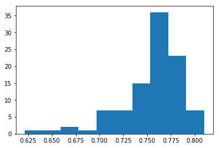

```
95.0 likelihood that the confidence interval of Linear Regression is  66.8 and 79.9 which covers the true skill of the model
```

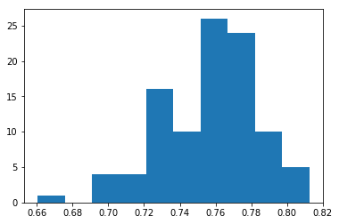

```
95.0 likelihood that the confidence interval of Linear ridge is  69.5 and 80.2 which covers the true skill of the model
```

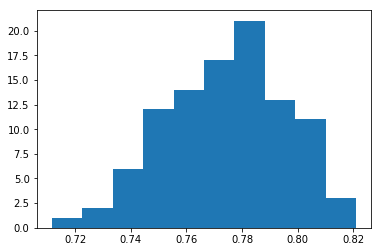

```
95.0 likelihood that the confidence interval of Linear Lasso is  73.2 and 81.0 which covers the true skill of the model
```

```python
n_iterations = 100
n_size = int(len(concrete_df2_norm_imp) * 0.5)

# run bootsrap
names = []
for names,models in Models_p:
    for i in range (n_iterations):
        X_trainp, X_testp, y_trainp, y_testp = train_test_split(X_poly,y,test_size = 0.3, random_state = None)
        #fit model
        models.fit(X_trainp,y_trainp)
        #evaluate model
        score = models.score(X_testp,y_testp)
        statistic.append(score)
    #plot scores
    plt.hist(statistic)
    plt.show()
    #confidence intervals
    alpha = 0.95
    p = ((1-alpha)/2) * 100
    lower = max(0.0,np.percentile(statistic,p))
    p = (alpha + ((1-alpha)/2)) * 100
    upper = min(1.0,np.percentile(statistic,p))
    print('%.1f likelihood that the confidence interval of %s is  %.1f and %.1f which covers the true skill of the model' %(alpha*100,names,lower*100, upper*100))
    statistic = []
    print('*' *100)
```

- CONFIDENCE INTERVAL CALCULATION FOR OTHER REGRESSION MODELS

```python
# Initiating Models
clfLR = LinearRegression()
clfridge = grid_search_ridge.best_estimator_
clflasso = grid_search_lasso.best_estimator_
final_KNNR = gs_knnr.best_estimator_
final_DTR = grid_search_DTR.best_estimator_
final_RFR = gs_rfr.best_estimator_
final_SVR = gs_svr.best_estimator_
final_GBR = gs_gbr.best_estimator_
final_XGBR = gs_xgbr.best_estimator_
```

```python
# Creating the matrix of models
Models = []
Models.append(('Linear Regression',clfLR))
Models.append(('Linear ridge',clfridge))
Models.append(('Linear Lasso',clflasso))
Models.append(('K-Nearest Neighbour',final_KNNR))
Models.append(('Decision Tree Regressor',final_DTR))
Models.append(('Random Forest Regressor', final_RFR))
Models.append(('Support Vector Regressor', final_SVR))
Models.append(('Gradent Boosting Regressor',final_GBR))
Models.append(('XG Boost Regressor',final_XGBR))
```

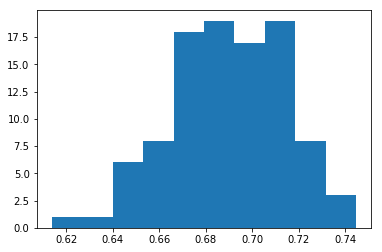

```
 The accuracy confidence interval of Linear Regression model lies between 64.5 and 73.3 with 95.0 likelihood
```

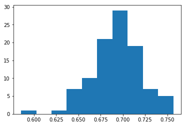

```
 The accuracy confidence interval of Linear ridge model lies between 63.8 and 74.8 with 95.0 likelihood
```

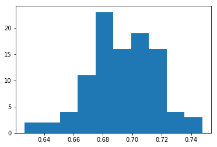

```
 The accuracy confidence interval of Linear Lasso model lies between 64.9 and 73.4 with 95.0 likelihood
```

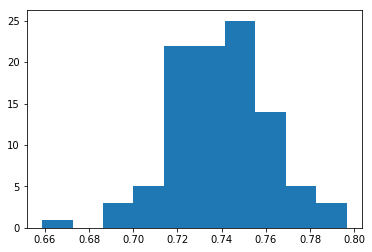

```
 The accuracy confidence interval of K-Nearest Neighbour model lies between 69.8 and 78.2 with 95.0 likelihood
```

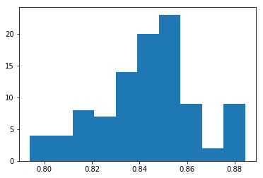

```
 The accuracy confidence interval of Decision Tree Regressor model lies between 79.9 and 88.0 with 95.0 likelihood
```

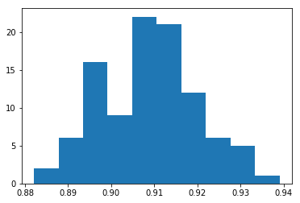

```
 The accuracy confidence interval of Random Forest Regressor model lies between 89.0 and 93.1 with 95.0 likelihood
```

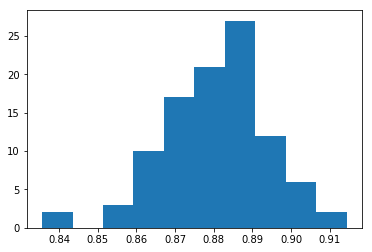

```
 The accuracy confidence interval of Support Vector Regressor model lies between 85.4 and 90.4 with 95.0 likelihood
```

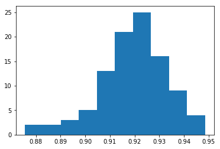

[output not shown]

[output cut: 75 more lines]

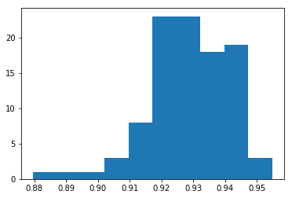

```
 The accuracy confidence interval of XG Boost Regressor model lies between 90.2 and 94.7 with 95.0 likelihood
```

```python
n_iterations = 100
n_size = int(len(concrete_df2_norm_imp) * 0.5)

# run bootsrap
statistic = []
names = []
lower = []
upper = []
for names,models in Models:
    for i in range (n_iterations):
        #prepare train and test sets
        X_train, X_test, y_train, y_test = train_test_split(X_z1,y,test_size = 0.3, random_state = None)
        #fit model
        models.fit(X_train,y_train)
        #evaluate model
        score = models.score(X_test,y_test)
        statistic.append(score)
    #plot scores
    plt.hist(statistic)
    plt.show()
    #confidence intervals
    alpha = 0.95
    p = ((1-alpha)/2) * 100
    lowrange = max(0.0,np.percentile(statistic,p))
    lower.append(lowrange)
    p = (alpha + ((1-alpha)/2)) * 100
    highrange = min(1.0,np.percentile(statistic,p))
    upper.append(highrange)
    msg = " The accuracy confidence interval of %s model lies between %.1f and %.1f with %.1f likelihood " %(names,lowrange*100, highrange*100, alpha*100)
    print(msg)
    statistic = []
    print('*' *100)
```

```python
dconfidence_interval1 = {'Classifiers': ['Linear Regession', 'Ridge','Lasso', 'K Nearest Neighbor Regressor', 'Decision Tree Regressor',
                          'Random Forest Regressor','Support Vector Regressor', 'Gradient Boosting Regressor','XG Boost Regressor'],
                     'Lower interval' : np.array(lower),
                     'upper interval' : np.array(upper)
         }
Classifier_CI1 = pd.DataFrame(data = dconfidence_interval1)
Classifier_CI1
```

|  | Classifiers | Lower interval | upper interval |
| --- | --- | --- | --- |
| 0 | Linear Regession | 0.644518 | 0.733052 |
| 1 | Ridge | 0.638277 | 0.748036 |
| 2 | Lasso | 0.649414 | 0.734479 |
| 3 | K Nearest Neighbor Regressor | 0.697914 | 0.782438 |
| 4 | Decision Tree Regressor | 0.799300 | 0.880413 |
| 5 | Random Forest Regressor | 0.890170 | 0.931204 |
| 6 | Support Vector Regressor | 0.853894 | 0.903908 |
| 7 | Gradient Boosting Regressor | 0.886862 | 0.942636 |
| 8 | XG Boost Regressor | 0.901851 | 0.947353 |

- The models that fall in the 85% to 95% confidence interval at 95% likelihood are Random Forest Regressor, Support Vector Regressor, Gradient Boosting Regressor and XG Boost Regressor

Conclusions